# MyHomework1

Mingming_Xu

2020/7/8

## Task 1 :about iowa set

### Load set

```r
iowa.df<-read.csv("data/iowa.csv",header = T,sep = ";")
iowa.df
```

```
##    Year Rain0 Temp1 Rain1 Temp2 Rain2 Temp3 Rain3 Temp4 Yield
## 1  1930 17.75  60.2  5.83  69.0  1.49  77.9  2.42  74.4  34.0
## 2  1931 14.76  57.5  3.83  75.0  2.72  77.2  3.30  72.6  32.9
## 3  1932 27.99  62.3  5.17  72.0  3.12  75.8  7.10  72.2  43.0
## 4  1933 16.76  60.5  1.64  77.8  3.45  76.4  3.01  70.5  40.0
## 5  1934 11.36  69.5  3.49  77.2  3.85  79.7  2.84  73.4  23.0
## 6  1935 22.71  55.0  7.00  65.9  3.35  79.4  2.42  73.6  38.4
## 7  1936 17.91  66.2  2.85  70.1  0.51  83.4  3.48  79.2  20.0
## 8  1937 23.31  61.8  3.80  69.0  2.63  75.9  3.99  77.8  44.6
## 9  1938 18.53  59.5  4.67  69.2  4.24  76.5  3.82  75.7  46.3
## 10 1939 18.56  66.4  5.32  71.4  3.15  76.2  4.72  70.7  52.2
## 11 1940 12.45  58.4  3.56  71.3  4.57  76.7  6.44  70.7  52.3
## 12 1941 16.05  66.0  6.20  70.0  2.24  75.1  1.94  75.1  51.0
## 13 1942 27.10  59.3  5.93  69.7  4.89  74.3  3.17  72.2  59.9
## 14 1943 19.05  57.5  6.16  71.6  4.56  75.4  5.07  74.0  54.7
```

[output cut: 19 more lines]

### The information about the set

1. The `iowa.df` has 33 rows and columns
2. The names of the columns of `iowa.df` are:

```r
colnames(iowa.df)
```

```
##  [1] "Year"  "Rain0" "Temp1" "Rain1" "Temp2" "Rain2" "Temp3" "Rain3" "Temp4"
## [10] "Yield"
```

3. The value of row 5, column 7 of `iowa.df` is: 79.7

```r
iowa.df[5,7]
```

```
## [1] 79.7
```

4. The display of the entire second row of `iowa.df`:

```r
iowa.df[2,]
```

```
##   Year Rain0 Temp1 Rain1 Temp2 Rain2 Temp3 Rain3 Temp4 Yield
## 2 1931 14.76  57.5  3.83    75  2.72  77.2   3.3  72.6  32.9
```

## Task 2 :about syntax and class-typing

### Number1 Explain

```r
vector1 <- c("5", "12", "7", "32")
max(vector1)
```

```
## [1] "7"
```

```r
sort(vector1)
```

```
## [1] "12" "32" "5"  "7"
```

1. The members of `vector1` are characters.They are sorted lexicographically in R.So the order of `vector1` is “12” “32” “5” “7” ,and the max member is “7”.
2. But `sum(vector1)` is wrong. Because function `sum()` can only be used in numeric or complex or logical vectors, it cannot be used in character vectors.

### Number2 Explain

```r
vector2 <- c("5",7,12)
vector2
```

```
## [1] "5"  "7"  "12"
```

These commands have error. Because “5” is character,non-numeric parameters. `c()` is used to just combine them together. The output type is determined from the highest type of the components in the hierarchy[**NULL < raw < logical < integer < double < complex < character < list < expression**]. Therefore in that situation, it creats a character vector, so `vector2[2] + vector2[3]` can’t run well.

```r
dataframe3 <- data.frame(z1="5",z2=7,z3=12)
dataframe3[1,2] + dataframe3[1,3]
```

```
## [1] 19
```

These commands lead the result : 19. Although “5” is character,non-numeric parameters,`data.frame()` creates data frames, that is a generic function, each component or column had been passed as a separate argument ,so methods can be written to change the behaviour of arguments according to their classes.

```r
list4 <- list(z1="6", z2=42, z3="49", z4=126)
list4[[2]]+list4[[4]]
```

```
## [1] 168
```

These commands lead the result : 168. Because `list[[i]]` return the i_th element of the list and the type of the result depends on the element itself.But `list[i]` get the i_th element of the list,and the type of the result is still list, so `list4[2]+list4[4]` can’t run well.

## Task 3 :working with functions and operations

### about `seq()`

```r
seq(from = 1,to = 10000,by = 372)
```

```
##  [1]    1  373  745 1117 1489 1861 2233 2605 2977 3349 3721 4093 4465 4837 5209
## [16] 5581 5953 6325 6697 7069 7441 7813 8185 8557 8929 9301 9673
```

```r
seq(from = 1,to = 10000,length.out  = 50)
```

```
##  [1]     1.0000   205.0612   409.1224   613.1837   817.2449  1021.3061
##  [7]  1225.3673  1429.4286  1633.4898  1837.5510  2041.6122  2245.6735
## [13]  2449.7347  2653.7959  2857.8571  3061.9184  3265.9796  3470.0408
## [19]  3674.1020  3878.1633  4082.2245  4286.2857  4490.3469  4694.4082
## [25]  4898.4694  5102.5306  5306.5918  5510.6531  5714.7143  5918.7755
## [31]  6122.8367  6326.8980  6530.9592  6735.0204  6939.0816  7143.1429
## [37]  7347.2041  7551.2653  7755.3265  7959.3878  8163.4490  8367.5102
## [43]  8571.5714  8775.6327  8979.6939  9183.7551  9387.8163  9591.8776
## [49]  9795.9388 10000.0000
```

### about `rep()`

```r
rep(1:3,times=3)
```

```
## [1] 1 2 3 1 2 3 1 2 3
```

```r
rep(1:3,each=3)
```

```
## [1] 1 1 1 2 2 2 3 3 3
```

`rep(1:3,times=3)` repeat “123” three times, when `rep(1:3,each=3)` repeat “1”,“2”,and“3” three times in turn.

## Task 3 :Book task

1. MB C.H 1.2

```r
data("orings")
orings_new<-orings[1:2,]
orings_new<-rbind(orings_new,orings[4,],orings[11,],orings[13,],orings[18,])
orings_new
```

```
##    Temperature Erosion Blowby Total
## 1           53       3      2     5
## 2           57       1      0     1
## 4           63       1      0     1
## 11          70       1      0     1
## 13          70       1      0     1
## 18          75       0      2     1
```

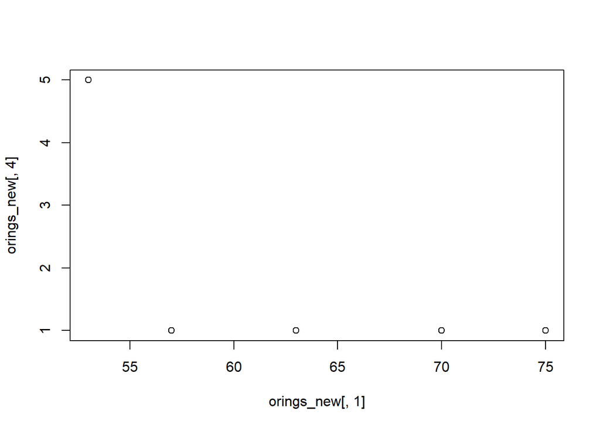

```r
plot(orings_new[,1],orings_new[,4])
```

2. MB C.H 1.4

```r
data("ais")
str(ais)
```

```
## 'data.frame':    202 obs. of  13 variables:
##  $ rcc   : num  3.96 4.41 4.14 4.11 4.45 4.1 4.31 4.42 4.3 4.51 ...
##  $ wcc   : num  7.5 8.3 5 5.3 6.8 4.4 5.3 5.7 8.9 4.4 ...
##  $ hc    : num  37.5 38.2 36.4 37.3 41.5 37.4 39.6 39.9 41.1 41.6 ...
##  $ hg    : num  12.3 12.7 11.6 12.6 14 12.5 12.8 13.2 13.5 12.7 ...
##  $ ferr  : num  60 68 21 69 29 42 73 44 41 44 ...
##  $ bmi   : num  20.6 20.7 21.9 21.9 19 ...
##  $ ssf   : num  109.1 102.8 104.6 126.4 80.3 ...
##  $ pcBfat: num  19.8 21.3 19.9 23.7 17.6 ...
##  $ lbm   : num  63.3 58.5 55.4 57.2 53.2 ...
##  $ ht    : num  196 190 178 185 185 ...
##  $ wt    : num  78.9 74.4 69.1 74.9 64.6 63.7 75.2 62.3 66.5 62.9 ...
##  $ sex   : Factor w/ 2 levels "f","m": 1 1 1 1 1 1 1 1 1 1 ...
##  $ sport : Factor w/ 10 levels "B_Ball","Field",..: 1 1 1 1 1 1 1 1 1 1 ...
```

```r
any(is.na(ais))
```

```
## [1] FALSE
```